# IE 360 Homework 1 - Selin Coşkun

In this homework, 4 time series data sets that are driven together in order to explain the movements in the output attribute which is the tourism data of Turkey between 2016 and 2021. These data are driven from https://evds2.tcmb.gov.tr/, https://www.who.int/ and https://trends.google.com/trends/. In order to see the explicit movements and to derive a correlation between these data, they are visualised via plots that are plotted in Jupyter Notebook using R programming language. The 4 attributes that were examined in order to see their correlation with the tourism data were:

Covid-19 data in which the number of daily new cases were aggregated with respect to months, Dolar/Try Exchange Rate data in which the average rates were calculated with respect to months, Google Trends data of "holiday turkey" searchs in google, scaled to numbers between 0 and 100, Google Trends data of "flight turkey" searchs in google, again scaled to numbers between 0 and 100.

## Adjusting the Data Sets

However, in order to work on these data sets, first thing to do is to install and call some packages, and the following thing to do is to get the csv files of data sets into R environment and adjusting the data.

```r
#install.packages("data.table")
#install.packages("https://cran.r-project.org/src/contrib/Archive/lubridate/lubridate_1.7.4.tar.gz",repos=NULL)
#install.packages("ggplot2")
#install.packages("ggcorrplot")
```

```r
library(data.table)
library(lubridate)
library(ggplot2)
library(ggcorrplot)
```

```r
tourist <- read.csv("total_visit.csv") #Number of tourists in Turkey in the respective month
usd <- read.csv("usd_try.csv") #Average USD/TRY exchange rate in the respective month
covid <- read.csv("covid19.csv") #Number of cases in Turkey in the respective month
google1 <- read.csv("holiday_turkey.csv") #Total number of google searchs in the world including 'holiday turkey' in the respective month
google2 <- read.csv("flight_turkey.csv") #Total number of google searchs in the world including 'flight turkey' in the respective month
```

```r
setDT(tourist)
tourist[,year:=year(ym(date))]
yearly_visit = tourist[,list(total_visit = sum(total_visit)),list(year)]
tourist[,month:=month(ym(date))]
```

```r
setDT(usd)
usd[,year:=year(ym(date))]
yearly_rate = usd[,list(yearly_rate = mean(rate)),list(year)]
usd[,month:=month(ym(date))]
```

```r
setDT(covid)
covid[,year:=year(ym(date))]
yearly_cases = covid[,list(yearly_cases = sum(case_number)),list(year)]
covid[,month:=month(ym(date))]
```

```r
setDT(google1)
google1[,year:=year(ym(date))]
yearly_search1 = google1[,list(yearly_search1 = sum(holiday_turkey)),list(year)]
google1[,month:=month(ym(date))]
```

```r
setDT(google2)
google2[,year:=year(ym(date))]
yearly_search2 = google2[,list(yearly_search2 = sum(flight_turkey)),list(year)]
google2[,month:=month(ym(date))]
```

## 1- Tourist Visits to Turkey

Since the main aim of the homework is to examine the behaviour of the number of tourists data, it is meaningful to first adjust and visualize this data set.

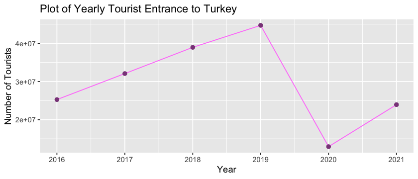

```r
options(repr.plot.width = 7, repr.plot.height =3)
ggplot(yearly_visit, aes(x= year, y=total_visit))+
geom_line(color="orchid1")+
geom_point(colour="orchid4", size = 2)+
ggtitle("Plot of Yearly Tourist Entrance to Turkey") +
xlab("Year") + ylab("Number of Tourists")
```

It can be seen from the yearly plot that the number of tourists had an increasing trend until 2020, and in 2020 the numbers have sharply dropped. After 2020, the numbers have increased with even bigger slope than it had before 2020. However, the 2021 tourist numbers have hardly reached the tourist numbers of 2016. The sharp drop in 2020 may be caused from the Covid19 cases that we will examine later, or the shutdowns related to the case numbers. The increase in 2021 with high positive trend may be caused by the number of people vaccinated and the releif that people acquire with the decreasing frequency of shutdowns. However, this is only the Covid19 side of the case. We have also the exchange rate to be considered.

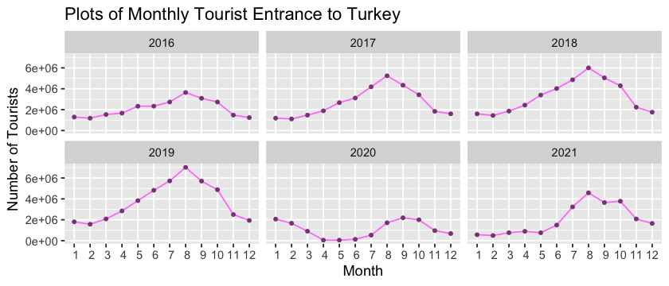

```r
ggplot(tourist, aes(x= month, y=total_visit))+geom_line(color="orchid1")+geom_point(colour="orchid4", size = 1)+
facet_wrap(~year)+
scale_x_discrete(limits=c(1:12))+
ggtitle("Plots of Monthly Tourist Entrance to Turkey") +
xlab("Month") + ylab("Number of Tourists")
```

From the monthly plots it can be seen that the tourism numbers rise in the summer period and reach their peak in August. The cause leading to this peak may be the hot weather that pushes people to go on a holiday, the holiday dates of the schools in Turkey and other countries, and maybe the fact that in 2017, 2018, 2019 and 2020, the Kurban Holiday was in August. Other than that, the winter season of years excluding the years with Covid, seem to have similar numbers of tourists. Additionally, the effect of Covid cases are obvious in the data beginning from February 2020 and it is visible that the numbers in especially April, May, June of 2020 and also in the beginning of 2021 when the shutdowns in Turkey were implemented.

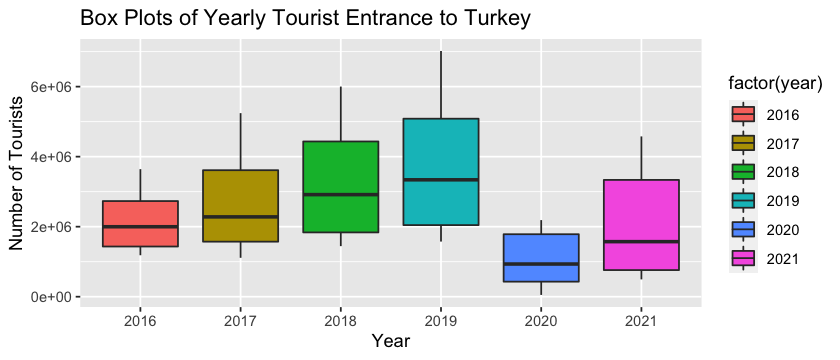

```r
ggplot(tourist,aes(x=factor(year),y=total_visit)) +
geom_boxplot(aes(fill = factor(year))) +
ggtitle("Box Plots of Yearly Tourist Entrance to Turkey") +
xlab("Year") + ylab("Number of Tourists")
```

From the box plots the variation and the distribution of the data can be seen. The peaks of the following years increase successively and the variation of the data also increases. The first four years' increasing trend and the sudden drop in 2020 can also be seen from the box plots. 2021's box plot indicates that the variation is high and the numbers which are low are more frequent according to the shape of the plot. That is probably because the number of Covid19 cases were really high in most of the times in 2021 but in the late-mids of 2021, people got vaccinated and the fear decreased.

## 2 - USD/TRY Exchange Rate

The yearly average exchange rate of USD/TRY have been increasing since 2016 and the slope of the increasing lines have been increasing except the slope of the line between 2018 and 2019. The increasing exchange rate of usd/try eventually decreases the purchasing power of people in Turkey and the number of Turkish tourists in Turkey may decrease. However, the increasing usd/try exchange rate means a decreasing try/usd and since most of the trade interactions in the world is done with dollars, and some major commodities are quoted in dollars (such as gold and petroleum), it has effect on most of the currencies. That means Turkish Lira becomes cheaper and Turkey becomes a cheap place to go on a holiday for most of the people from different countries. That's why, the ever increasing interest rate affects people earning money with Turkish Lira (mostly people live in Turkey) negatively so that the number of people go on a holiday decreases, but on the other side, the number of tourists come from abroad increases. So, the number of total tourists increase mostly every year. Maybe, this fact affects the increase in the tourism data in October 2021 while the exchange rate was also increasing rapidly, because in the other years there is not such an increase in the tourism numbers in October. This rapid increase in exchange rate at the end of 2021 can also be seen from the outliers in the box plots of exhange rate.

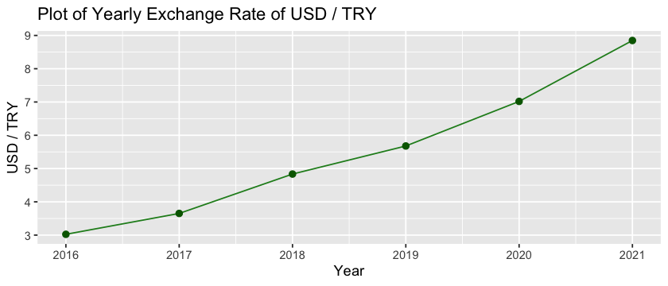

```r
ggplot(yearly_rate, aes(x= year, y=yearly_rate))+
geom_line(color="forestgreen")+
geom_point(colour="darkgreen", size = 2)+
ggtitle("Plot of Yearly Exchange Rate of USD / TRY") +
xlab("Year") + ylab("USD / TRY")
```

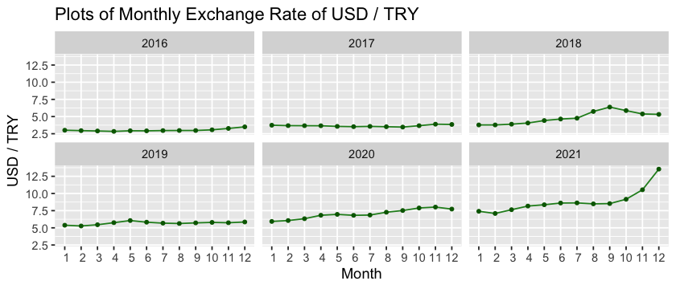

```r
ggplot(usd, aes(x = month, y = rate))+geom_line(color="forestgreen")+geom_point(colour = "darkgreen", size = 1)+
facet_wrap(~year)+
scale_x_discrete(limits=c(1:12))+
ggtitle("Plots of Monthly Exchange Rate of USD / TRY") +
xlab("Month") + ylab("USD / TRY")
```

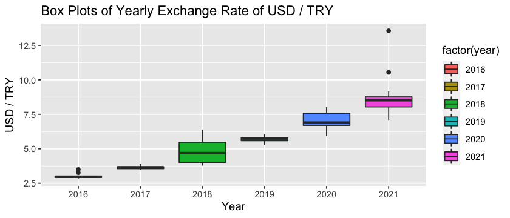

```r
ggplot(usd,aes(x=factor(year),y=rate)) +
geom_boxplot(aes(fill = factor(year)))+
ggtitle("Box Plots of Yearly Exchange Rate of USD / TRY") +
xlab("Year") + ylab("USD / TRY")
```

## 3 - Number of Covid19 Cases

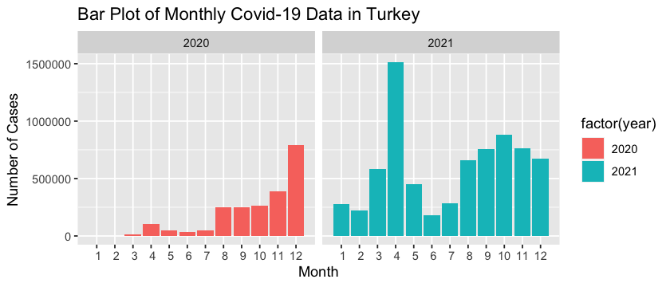

```r
ggplot(covid, aes(x = month, y=case_number)) +
geom_bar(stat='identity', aes(fill = factor(year))) + facet_wrap(~year)+
scale_x_discrete(limits=c(1:12))+
ggtitle("Bar Plot of Monthly Covid-19 Data in Turkey") +
xlab("Month") + ylab("Number of Cases")
```

In the bar plots displaying the Covid-19 data, the number of cases in 2021 are spectacularly higher than the number of cases in 2020. However, in 2020, the global pandemic Covid-19 was new to people and it people were horrified. Additionally, in 2021, the vaccine was found, distributed and started to be implemented on people. Additionally, the shutdowns in 2020 were more strict and longer comparing to the shutdowns in 2021 and the holiday resorts, cafes, restaurants and sightseeing places in Turkey were closed for a long time with the government order in 2020. Therefore, despite the lower number of cases in 2020, the tourism numbers were highly affected in 2020.

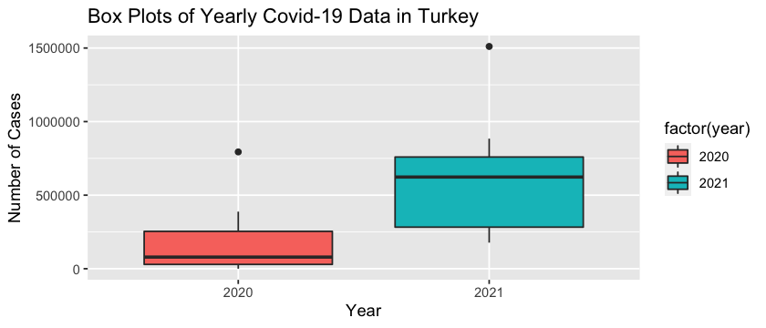

```r
ggplot(covid,aes(x=factor(year),y=case_number)) + geom_boxplot(aes(fill = factor(year)))+
ggtitle("Box Plots of Yearly Covid-19 Data in Turkey") +
xlab("Year") + ylab("Number of Cases")
```

The box plots of covid cases also demonstrates that the number of cases are considerably higher in 2021 than 2020. Additionally, each of the years have one outlier point which indicates the December od 2020 and April of 2021 in which the number of new cases have astronomically increased.

## 4 - Google Search: "Holiday Turkey"

The Google Trends data indicates the number of searches done in Google including the specified words, in our case "Holiday Turkey".

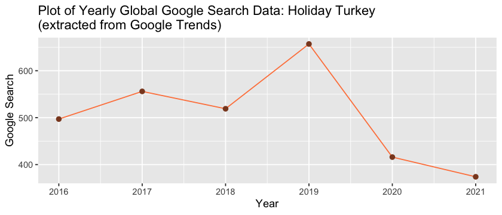

```r
ggplot(yearly_search1, aes(x= year, y=yearly_search1))+
geom_line(color="sienna1")+
geom_point(colour="sienna4", size = 2)+
ggtitle("Plot of Yearly Global Google Search Data: Holiday Turkey \n(extracted from Google Trends)") +
xlab("Year") + ylab("Google Search")
```

The trend seems to be in line with the tourism data in 2016, 2017, 2019 and 2020. However, in 2018 and 2021, the search numbers do not seem to be representing the tourism data. Probably in 2021, a considerable amount of tourists were from Turkey because of the travel limitations caused by Covid-19 pandemic, and the people from Turkey search for some more specific words or words in Turkish, or maybe travel without the need of Google Search.

[figure not shown]

```r
options(repr.plot.width = 10, repr.plot.height =3)
ggplot(google1, aes(x = month, y = holiday_turkey))+
geom_line(color="sienna1")+geom_point(colour = "sienna4", size = 1)+
facet_wrap(~year)+
scale_x_discrete(limits=c(1:12))+
ggtitle("Plots of Monthly Global Google Search Data: Holiday Turkey \n(extracted from Google Trends)") +
xlab("Month") + ylab("Google Search [0,100]")
```

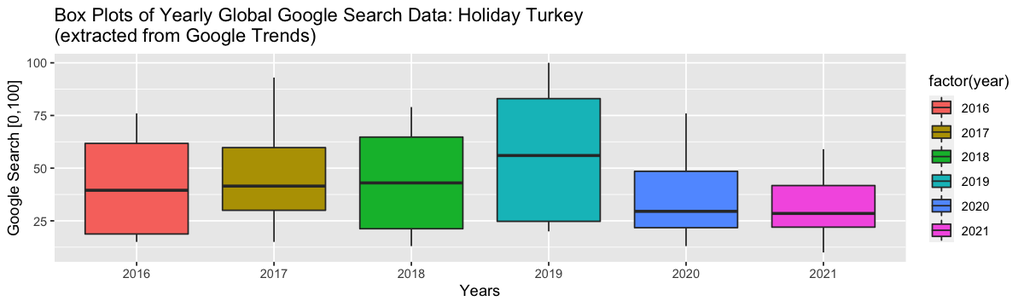

```r
ggplot(google1,aes(x=factor(year),y=holiday_turkey)) +
geom_boxplot(aes(fill = factor(year))) +
ggtitle("Box Plots of Yearly Global Google Search Data: Holiday Turkey \n(extracted from Google Trends)") +
xlab("Years") + ylab("Google Search [0,100]")
```

In the box plots of the yearly search data including "Holiday Turkey", it can be seen that the means of 2016, 2017 and 2018 data are really close to each other. In 2017, the variation of data is lower than the other two however, the maximum point of 2017 data is quite higher than the others. In 2019 on the other hand, the median reaches the highest point of 5 years data, the highest number of searchs is done in a month of 2019, and the variation of search data in 2019 is the highest. In 2020 and 2021, the years in which Covid-19 pandemic affected the tourism numbers negatively in all over the world, apparently also the Google search numbers for "Holiday Turkey" had been highly affected negatively. Because, the medians of 2020 and 2021 data are exceptionally low. However in 2020, the maximum number of search is higher than 2021's. The reason for that may be the poor Covid-19 policies and the case numbers which are greater than of some countries that the tourists can visit rather than Turkey.

## 5 - Google Search: "Flight Turkey"

The Google Trends data indicates the number of searchs done in Google including the specified words, in our case "Flight Turkey".

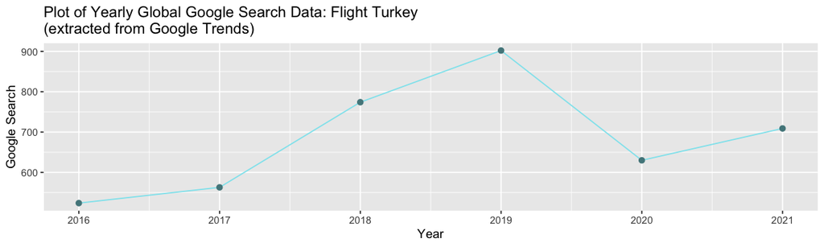

```r
ggplot(yearly_search2, aes(x= year, y=yearly_search2))+
geom_line(color="cadetblue2")+
geom_point(colour="cadetblue4", size = 2)+
ggtitle("Plot of Yearly Global Google Search Data: Flight Turkey \n(extracted from Google Trends)") +
xlab("Year") + ylab("Google Search")
```

As it can be seen from the yearly plot of google search numbers including "Flight Turkey", in 2019, people had searched for a flight in Turkey or to Turkey the most. And from 2020's data, it can be seen that it was lower than 2019, but higher than 2016 and 2017 on the contrary to "Holiday Turkey" search data. The cause of this difference in search data may be the difference between the search purposes. People may search for flight turkey with different purposes than scheduling a flight holiday, they may go on business trips or visit their countries. In 2020, so many people went back to their countries, especially students, because of the pandemic.

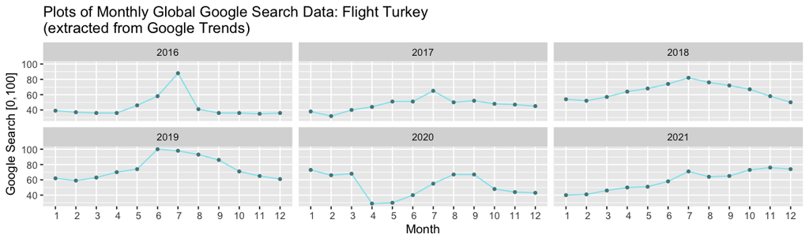

```r
options(repr.plot.width = 10, repr.plot.height =3)
ggplot(google2, aes(x = month, y = flight_turkey))+
geom_line(color="cadetblue2")+geom_point(colour = "cadetblue4", size = 1)+
facet_wrap(~year)+
scale_x_discrete(limits=c(1:12))+
ggtitle("Plots of Monthly Global Google Search Data: Flight Turkey \n(extracted from Google Trends)") +
xlab("Month") + ylab("Google Search [0,100]")
```

[figure not shown]

```r
ggplot(google2,aes(x=factor(year),y=flight_turkey)) +
geom_boxplot(aes(fill = factor(year))) +
ggtitle("Box Plots of Yearly Global Google Search Data: Flight Turkey \n(extracted from Google Trends)") +
xlab("Years") + ylab("Google Search [0,100]")
```

The boxplots of the search data for flight Turkey indicates that the highest numbers are in 2019, and the first positive, then negative and then again positive trend as we have seen in the monthly plots in the previous figure. However in these boxplots, the additional things that can be seen are the outliers and the variations of the data. In 2016, there are two outliers which are probably the June and July of the respective year; and in 2017, there is one outlier which is probably the July of the respective year. In these months, there occurs an unexpected rise in the search numbers most probably because of the holiday period, and the end of schools for students who study abroad.

## Aggregating Data

In order to analyse the data as a whole, the data is merged and a data frame is constructed.

```r
merged1 <- merge(tourist, usd, by = "date", all.x=TRUE)
merged2 <- merge(google1, google2, by = "date", all.x=TRUE)
merged3 <- merge(merged1, merged2, by = "date", all.x=TRUE)
merged <- merge(merged3, covid, by = "date", all.x=TRUE)
#str(merged)
df = subset(merged, select = -c(year.x.x, month.x.x, year.y.x, month.y.x, year.x.y, month.x.y, year.y.y, month.y.y, year, month) )
setDT(df)
na_index = which(is.na(df$case_number))
df[na_index,"case_number"] = 0
#df[,year_of_date := year(ym(date))]
df
str(df)
```

| date | total_visit | rate | holiday_turkey | flight_turkey | case_number |
| --- | --- | --- | --- | --- | --- |
| 2016-01 | 1296726 | 3.01 | 15 | 39 | 0 |
| 2016-02 | 1183830 | 2.95 | 26 | 37 | 0 |
| 2016-03 | 1533990 | 2.90 | 16 | 36 | 0 |
| 2016-04 | 1667413 | 2.84 | 35 | 36 | 0 |
| 2016-05 | 2329031 | 2.93 | 67 | 46 | 0 |
| 2016-06 | 2334127 | 2.92 | 76 | 58 | 0 |
| 2016-07 | 2733909 | 2.96 | 75 | 88 | 0 |
| 2016-08 | 3642977 | 2.97 | 60 | 41 | 0 |
| 2016-09 | 3089623 | 2.97 | 44 | 36 | 0 |
| 2016-10 | 2730649 | 3.07 | 46 | 36 | 0 |
| 2016-11 | 1479030 | 3.27 | 18 | 35 | 0 |
| 2016-12 | 1244101 | 3.50 | 19 | 36 | 0 |
| 2017-01 | 1184957 | 3.74 | 15 | 38 | 0 |
| 2017-02 | 1110950 | 3.68 | 36 | 32 | 0 |
| 2017-03 | 1476386 | 3.67 | 33 | 40 | 0 |
| 2017-04 | 1889519 | 3.66 | 52 | 44 | 0 |
| 2017-05 | 2670106 | 3.57 | 83 | 51 | 0 |
| 2017-06 | 3115407 | 3.53 | 68 | 51 | 0 |
| 2017-07 | 4188105 | 3.57 | 57 | 65 | 0 |
| 2017-08 | 5242858 | 3.52 | 93 | 50 | 0 |
| 2017-09 | 4339345 | 3.47 | 46 | 52 | 0 |
| 2017-10 | 3421449 | 3.67 | 37 | 48 | 0 |
| 2017-11 | 1836496 | 3.89 | 21 | 47 | 0 |
| 2017-12 | 1603949 | 3.85 | 15 | 45 | 0 |
| 2018-01 | 1601862 | 3.78 | 13 | 54 | 0 |
| 2018-02 | 1444008 | 3.78 | 22 | 52 | 0 |
| 2018-03 | 1862961 | 3.89 | 27 | 57 | 0 |
| 2018-04 | 2433008 | 4.06 | 37 | 64 | 0 |
| 2018-05 | 3398215 | 4.42 | 63 | 68 | 0 |
| 2018-06 | 4023879 | 4.64 | 70 | 74 | 0 |
| ... | ... | ... | ... | ... | ... |
| 2019-07 | 5717804 | 5.68 | 100 | 98 | 0 |
| 2019-08 | 7018257 | 5.63 | 84 | 93 | 0 |
| 2019-09 | 5702078 | 5.72 | 66 | 86 | 0 |
| 2019-10 | 4878255 | 5.79 | 62 | 71 | 0 |
| 2019-11 | 2501695 | 5.74 | 20 | 65 | 0 |
| 2019-12 | 1935290 | 5.85 | 22 | 61 | 0 |
| 2020-01 | 2065570 | 5.93 | 18 | 73 | 0 |
| 2020-02 | 1664208 | 6.06 | 30 | 66 | 0 |
| 2020-03 | 906067 | 6.33 | 29 | 68 | 10827 |
| 2020-04 | 50630 | 6.83 | 26 | 29 | 106762 |
| 2020-05 | 51588 | 6.96 | 37 | 30 | 45514 |
| 2020-06 | 128861 | 6.82 | 23 | 40 | 35510 |
| 2020-07 | 529990 | 6.86 | 48 | 55 | 51468 |
| 2020-08 | 1712380 | 7.27 | 76 | 67 | 247285 |
| 2020-09 | 2187683 | 7.52 | 50 | 67 | 250626 |
| 2020-10 | 2000557 | 7.89 | 50 | 48 | 264512 |
| 2020-11 | 960402 | 8.02 | 16 | 44 | 387925 |
| 2020-12 | 681408 | 7.73 | 13 | 43 | 793843 |
| 2021-01 | 570447 | 7.41 | 10 | 40 | 276629 |
| 2021-02 | 494337 | 7.09 | 12 | 41 | 222263 |
| 2021-03 | 761443 | 7.64 | 19 | 46 | 584716 |
| 2021-04 | 895342 | 8.17 | 32 | 50 | 1510820 |
| 2021-05 | 757518 | 8.36 | 51 | 51 | 454211 |
| 2021-06 | 1491955 | 8.61 | 26 | 58 | 177245 |
| 2021-07 | 3231555 | 8.63 | 59 | 71 | 284557 |
| 2021-08 | 4578265 | 8.49 | 41 | 64 | 661725 |
| 2021-09 | 3648131 | 8.53 | 28 | 65 | 758528 |
| 2021-10 | 3777732 | 9.16 | 44 | 73 | 884074 |
| 2021-11 | 2080510 | 10.54 | 29 | 76 | 761332 |
| 2021-12 | 1652786 | 13.55 | 23 | 74 | 671392 |

```
Classes ‘data.table’ and 'data.frame':	72 obs. of  6 variables:
 $ date          : Factor w/ 72 levels "2016-01","2016-02",..: 1 2 3 4 5 6 7 8 9 10 ...
 $ total_visit   : int  1296726 1183830 1533990 1667413 2329031 2334127 2733909 3642977 3089623 2730649 ...
 $ rate          : num  3.01 2.95 2.9 2.84 2.93 2.92 2.96 2.97 2.97 3.07 ...
 $ holiday_turkey: int  15 26 16 35 67 76 75 60 44 46 ...
 $ flight_turkey : int  39 37 36 36 46 58 88 41 36 36 ...
 $ case_number   : int  0 0 0 0 0 0 0 0 0 0 ...
 - attr(*, ".internal.selfref")=<externalptr>
 - attr(*, "sorted")= chr "date"
```

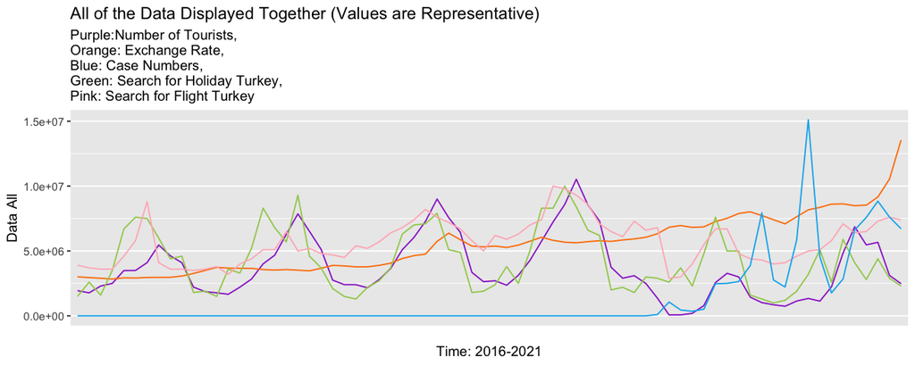

```r
options(repr.plot.width = 10, repr.plot.height =4)
ggplot(df, aes(x = as.numeric(date)))+
       geom_line(aes(y = 1.5*total_visit), color = "darkorchid3")+
       geom_line(aes(y = 1000000*rate), color = "darkorange1")+
       geom_line(aes(y = 100000*holiday_turkey), color = "darkolivegreen3")+
       geom_line(aes(y = 100000*flight_turkey), color = "lightpink")+
       geom_line(aes(y = 10*case_number), color = "deepskyblue2")+
scale_x_discrete(limits=c(2016,2017,2018,2019,2020,2021))+
ggtitle("All of the Data Displayed Together (Values are Representative)", subtitle = "Purple:Number of Tourists, \nOrange: Exchange Rate, \nBlue: Case Numbers, \nGreen: Search for Holiday Turkey, \nPink: Search for Flight Turkey") +
xlab("Time: 2016-2021") + ylab("Data All")
```

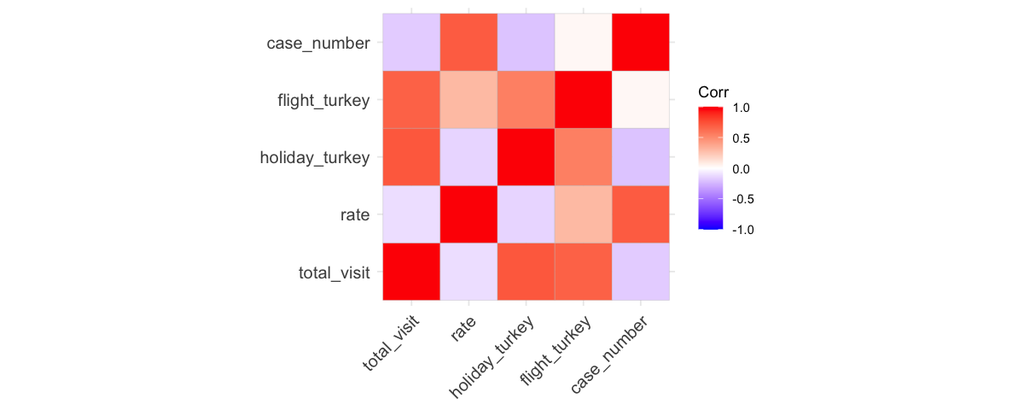

```r
options(repr.plot.width = 10, repr.plot.height =4)
ggcorrplot(cor(df[,-1]))
```

Since the main aim in this homework is to find the correlations between number of tourists in Turkey and other four parameters; in the correlation plot of the data frame, we should check the last row excluding the first column's output in the last row (because it shows the correlation of tourist numbers with itself). The correlation between exchange rate and tourist number, and between the number of Covid-19 cases and tourist numbers are negative, meaning that an increase in exchange rate and case numbers affect tourism in a negative way and leads the number of tourists to decrease. On the other hand, an increase in the search numbers of "Holiday Turkey" and "Flight Turkey" terms affect tourism in a positive way and causes the number of tourists to increase.

## Conclusion

In this homework, the main aim was to observe the 5 different time series data sets and to realize the correlation between four of them and the main one. All of the data sets were taken monthly from the sources. The main time series data set was the number of tourists in Turkey and the other time series data sets were the USD/TRY exchange rate, Covid-19 case numbers and number of Google searches including "Holiday Turkey" and "Flight Turkey" seperately. First, these data sets were examined seperately, they were visualized by yearly and monthly plots, boxplots and barplots. After that, the individual data frames were aggregated into a bigger data frame named df. Then df is visualized and analyzed. After that, the correlation plot of these data sets is shown and analyzed. The result of the correlation plot is aligned with the previous plots of Google Trend data and Covid-19 case number. However, the usd/try exchange rate correlation with tourism data does not match with the previous plot. The reason behind this is most probably the covid cases because the trend of exchange rate does not change so much, but the covid cases affect tourism so strong that the trends are distorted.